# Determining Whether or Not Someone Is a Good Credit Card Candidate

## Oversample Data

```python
#now let's look at oversampled data
xgb_clf_overfit = xgb.XGBClassifier()
xgb_clf_overfit.fit(x_oversample, y_oversample)
y_os_xgb_train_pred = xgb_clf_overfit.predict(x_train)
y_os_xgb_test_pred = xgb_clf_overfit.predict(x_test)
print("Training oversampled accuracy: ", accuracy_score(y_train, y_os_xgb_train_pred))
print("Testing oversampled accuracy: ", accuracy_score(y_test, y_os_xgb_test_pred))
xgb_os_report = classification_report(y_test, y_os_xgb_test_pred)
print(xgb_os_report)
f1_score_os_xgb = f1_score(y_test, y_os_xgb_test_pred, average = 'weighted')
print("F1 Score: ", f1_score_os_xgb)
precision_score_os_xgb = precision_score(y_test, y_os_xgb_test_pred, average = 'weighted')
print("Precision Score: ", precision_score_os_xgb)
```

```
Training oversampled accuracy:  0.8808732795443759
Testing oversampled accuracy:  0.8226114970301017
              precision    recall  f1-score   support

           0       0.87      0.90      0.89      7816
           1       0.60      0.52      0.56      2117

    accuracy                           0.82      9933
   macro avg       0.74      0.71      0.72      9933
weighted avg       0.81      0.82      0.82      9933

F1 Score:  0.8180393456028696
Precision Score:  0.8149974632130924
```

```python
#look at the training set for oversampled data
xgb_os_report_train = classification_report(y_train, y_os_xgb_train_pred)
print(xgb_os_report_train)
f1_score_os_xgb_train = f1_score(y_train, y_os_xgb_train_pred, average = 'weighted')
print("F1 Score: ", f1_score_os_xgb_train)
precision_score_os_xgb_train = precision_score(y_train, y_os_xgb_train_pred, average = 'weighted')
print("Precision Score: ", precision_score_os_xgb_train)
```

```
              precision    recall  f1-score   support

           0       0.91      0.94      0.93     18237
           1       0.74      0.67      0.71      4940

    accuracy                           0.88     23177
   macro avg       0.83      0.81      0.82     23177
weighted avg       0.88      0.88      0.88     23177

F1 Score:  0.8786610924190407
Precision Score:  0.8774335840888972
```

## K-Fold Cross Validation

```python
xgb_steps = [('over', SMOTENC(categorical_features = cat_cols)), ('model', xgb_clf)]
pipeline = Pipeline(steps=xgb_steps)
scoring = ["accuracy", "roc_auc", "precision", "recall", "f1_weighted"]
cv = StratifiedKFold(n_splits=5)
xgb_scores = cross_validate(pipeline, x_train, y_train, scoring=scoring, cv=cv, n_jobs=-1, return_train_score = True)
print(xgb_scores)
```

```
{'fit_time': array([10.209553  , 10.25082326, 10.23050404, 10.29701614,  9.9998312 ]), 'score_time': array([0.04739904, 0.03752494, 0.03889298, 0.04476881, 0.05243683]), 'test_accuracy': array([0.83067299, 0.82981018, 0.83042071, 0.82783172, 0.82265372]), 'train_accuracy': array([0.88306995, 0.88371…
```

```python
for key, value in xgb_scores.items():
    print("XGBoost model", key, "mean:", np.mean(value), ", std. dev:", np.std(value))
#looking @ training metrics:
#accuracy = 0.8861, roc_auc = 0.9264, precision = 0.7634, recall = 0.6748, f1_weighted = 0.8835
```

```
XGBoost model fit_time mean: 10.197545528411865 , std. dev: 0.10300904660434664
XGBoost model score_time mean: 0.04420452117919922 , std. dev: 0.005497700080444731
XGBoost model test_accuracy mean: 0.8282778648036612 , std. dev: 0.0029835035272599195
XGBoost model train_accuracy mean: 0.8861047005406151 , std. dev: 0.00264740388537981
XGBoost model test_roc_auc mean: 0.8184552306538521 , std. dev: 0.009144545665827194
XGBoost model train_roc_auc mean: 0.9264632065929282 , std. dev: 0.0031031105617267407
XGBoost model test_precision mean: 0.6124290065136746 , std. dev: 0.009732785398615539
XGBoost model train_precision mean: 0.7634281857675156 , std. dev: 0.007968234225763808
XGBoost model test_recall mean: 0.5301619433198381 , std. dev: 0.02061798279596964
XGBoost model train_recall mean: 0.6747975708502023 , std. dev: 0.007657268909285427
XGBoost model test_f1_weighted mean: 0.8236003541012845 , std. dev: 0.003419234667746763
XGBoost model train_f1_weighted mean: 0.8834768465544801 , std. dev: 0.0026948801662890222
```

## Hyperparameter Tuning

Hyperparameter Tuning is a common practice used to optimize the performance of a model. This involves setting a range of values for certain parameters for a given model, and I will use the model that has the best hyperparameters for each model.

```python
from sklearn.model_selection import RandomizedSearchCV
xgb_model = xgb.XGBClassifier()
xgb_params = {'gamma': [0.5, 1, 2.5, 5],
              'max_depth': [2, 3, 5, 7],
              'min_child_weight': [1, 5, 10],
              'subsample': [0.5, 0.6, 0.7, 0.8, 0.9, 1],
              'colsample_bytree': [0.5, 0.6, 0.7, 0.8, 0.9, 1]
             }
xgb_model_clf = RandomizedSearchCV(xgb_model, xgb_params, cv = 5, n_jobs = -1, scoring = "f1_weighted")
xgb_model_clf.fit(x_oversample, y_oversample)
```

```
RandomizedSearchCV(cv=5,
                   estimator=XGBClassifier(base_score=None, booster=None,
                                           callbacks=None,
                                           colsample_bylevel=None,
                                           colsample_bynode=None,
                                           colsample_bytree=None, device=None,
                                           early_stopping_rounds=None,
                                           enable_categorical=False,
                                           eval_metric=None, feature_types=None,
                                           gamma=None, grow_policy=None,
                                           importance_type=None,
                                           interaction_constraints=None,
                                           learning_rate...
                                           min_child_weight=None, missing=nan,
                                           monotone_constraints=None,
                                           multi_strategy=None,
                                           n_estimators=None, n_jobs=None,
                                           num_parallel_tree=None,
                                           random_state=None, ...),
                   n_jobs=-1,
                   param_distributions={'colsample_bytree': [0.5, 0.6, 0.7, 0.8,
                                                             0.9, 1],
                                        'gamma': [0.5, 1, 2.5, 5],
                                        'max_depth': [2, 3, 5, 7],
                                        'min_child_weight': [1, 5, 10],
                                        'subsample': [0.5, 0.6, 0.7, 0.8, 0.9,
                                                      1]},
                   scoring='f1_weighted')
```

```python
#best parameters
xgb_best_params = xgb_model_clf.best_params_
print(xgb_best_params)
```

```
{'subsample': 0.6, 'min_child_weight': 5, 'max_depth': 7, 'gamma': 0.5, 'colsample_bytree': 1}
```

```python
y_train_best_xgb = xgb_model_clf.predict(x_train)
print("XGB hyperparameter training accuracy: ", accuracy_score(y_train, y_train_best_xgb))
xgb_hyper_report = classification_report(y_train_best_xgb, y_train)
print(xgb_hyper_report)
f1_hyper_xgb = f1_score(y_train, y_train_best_xgb, average = 'weighted')
print("F1 hyperparameter score: ", f1_hyper_xgb)
precision_hyper_xgb = precision_score(y_train, y_train_best_xgb, average = 'weighted')
print("Precision hyperparameter score: ", precision_hyper_xgb)
```

```
XGB hyperparameter training accuracy:  0.8840661000129438
              precision    recall  f1-score   support

           0       0.94      0.92      0.93     18632
           1       0.69      0.75      0.72      4545

    accuracy                           0.88     23177
   macro avg       0.81      0.83      0.82     23177
weighted avg       0.89      0.88      0.89     23177

F1 hyperparameter score:  0.8822731188034576
Precision hyperparameter score:  0.8811784084478361
```

## K-fold Cross Validation on Hyperparameter-Tuned Model

```python
xgb_hyp_steps = [('over', SMOTENC(categorical_features = cat_cols)), ('model', xgb_model_clf)]
pipeline = Pipeline(steps=xgb_hyp_steps)
cv = StratifiedKFold(n_splits=5)
scoring = ["accuracy", "roc_auc", "precision", "recall", "f1_weighted"]
xgb_hyp_scores = cross_validate(pipeline, x_train, y_train, scoring=scoring, cv=cv, n_jobs=-1, return_train_score = True)
print(xgb_hyp_scores)
```

```
{'fit_time': array([32.78542161, 32.14440918, 32.29700518, 32.96552706, 32.03237104]), 'score_time': array([0.04642224, 0.06847167, 0.0445776 , 0.04026294, 0.1205101 ]), 'test_accuracy': array([0.83175151, 0.82657463, 0.82179072, 0.82912621, 0.82437972]), 'train_accuracy': array([0.90512917, 0.86246…
```

```python
for key, value in xgb_hyp_scores.items():
    print("XGBooost Hyperparameter model", key, "mean:", np.mean(value), ", std. dev:", np.std(value))
#looking @ training metrics:
#accuracy = 0.8926, roc_auc = 0.9330, precision = 0.7792, recall = 0.6926, f1_weighted = 0.8903
```

```
XGBooost Hyperparameter model fit_time mean: 32.44494681358337 , std. dev: 0.36588392703042993
XGBooost Hyperparameter model score_time mean: 0.0640489101409912 , std. dev: 0.029876515098405738
XGBooost Hyperparameter model test_accuracy mean: 0.8267245598212201 , std. dev: 0.0034900335316291773
XGBooost Hyperparameter model train_accuracy mean: 0.892608862001276 , std. dev: 0.015564489577986862
XGBooost Hyperparameter model test_roc_auc mean: 0.8177277203443083 , std. dev: 0.008811473184064533
XGBooost Hyperparameter model train_roc_auc mean: 0.9330164032932439 , std. dev: 0.02124916147038776
XGBooost Hyperparameter model test_precision mean: 0.6081717234238094 , std. dev: 0.005926994269315773
XGBooost Hyperparameter model train_precision mean: 0.7791984789925316 , std. dev: 0.04194679820407775
XGBooost Hyperparameter model test_recall mean: 0.5251012145748988 , std. dev: 0.023809316969509508
XGBooost Hyperparameter model train_recall mean: 0.6926113360323887 , std. dev: 0.03479463556260981
XGBooost Hyperparameter model test_f1_weighted mean: 0.8218853351649711 , std. dev: 0.004768521039807467
XGBooost Hyperparameter model train_f1_weighted mean: 0.8902617866411715 , std. dev: 0.01581008942549442
```

# Random Forest Model

Random Forest models randomly select subsets of data from the given dataset and makes a decision tree for each subset. Each decision tree, based on the data that it was derived from, will make a decision on the outcome variable. The random forest as a whole will then make a decision on the outcome variable based on the decisions of the decision trees that were created within the model.

```python
from sklearn.ensemble import RandomForestClassifier
rf_clf = RandomForestClassifier()
rf_clf.fit(x_train, y_train)
y_rf_train_pred = rf_clf.predict(x_train)
y_rf_test_pred = rf_clf.predict(x_test)
print("Training accuracy: ", accuracy_score(y_train, y_rf_train_pred))
print("Testing accuracy: ", accuracy_score(y_test, y_rf_test_pred))
rf_report = classification_report(y_test, y_rf_test_pred)
print(rf_report)
f1_score_rf = f1_score(y_test, y_rf_test_pred, average = 'weighted')
print("F1 Score: ", f1_score_rf)
precision_score_rf = precision_score(y_test, y_rf_test_pred, average = 'weighted')
print("Precision Score: ", precision_score_rf)
```

```
Training accuracy:  0.9892997368080425
Testing accuracy:  0.8572435316621363
              precision    recall  f1-score   support

           0       0.89      0.94      0.91      7816
           1       0.71      0.55      0.62      2117

    accuracy                           0.86      9933
   macro avg       0.80      0.75      0.77      9933
weighted avg       0.85      0.86      0.85      9933

F1 Score:  0.8501402173024859
Precision Score:  0.8488747651908112
```

```python
#lets do the same for training data
rf_report_train = classification_report(y_train, y_rf_train_pred)
print(rf_report_train)
f1_score_rf_train = f1_score(y_train, y_rf_train_pred, average = 'weighted')
print("F1 Score: ", f1_score_rf_train)
precision_score_rf_train = precision_score(y_train, y_rf_train_pred, average = 'weighted')
print("Precision Score: ", precision_score_rf_train)
```

```
              precision    recall  f1-score   support

           0       0.99      0.99      0.99     18237
           1       0.98      0.97      0.97      4940

    accuracy                           0.99     23177
   macro avg       0.98      0.98      0.98     23177
weighted avg       0.99      0.99      0.99     23177

F1 Score:  0.9892894314184804
Precision Score:  0.9892828121656335
```

These metrics above are crazy good, and really go to show how well random forests work with classification problems.

## Oversample data

```python
rf_oversampled_clf = RandomForestClassifier()
rf_oversampled_clf.fit(x_oversample, y_oversample)
y_rf_os_train_pred = rf_oversampled_clf.predict(x_train)
y_rf_os_test_pred = rf_oversampled_clf.predict(x_test)
print("Training oversampled accuracy: ", accuracy_score(y_train, y_rf_os_train_pred))
print("Testing oversampled accuracy: ", accuracy_score(y_test, y_rf_os_test_pred))
rf_os_report = classification_report(y_test, y_rf_os_test_pred)
print(rf_os_report)
f1_score_rf_os = f1_score(y_test, y_rf_os_test_pred, average = 'weighted')
print("F1 Score: ", f1_score_rf_os)
precision_score_rf_os = precision_score(y_test, y_rf_os_test_pred, average = 'weighted')
print("Precision Score: ", precision_score_rf_os)
```

```
Training oversampled accuracy:  0.9892997368080425
Testing oversampled accuracy:  0.8371086278063022
              precision    recall  f1-score   support

           0       0.89      0.90      0.90      7816
           1       0.62      0.60      0.61      2117

    accuracy                           0.84      9933
   macro avg       0.76      0.75      0.75      9933
weighted avg       0.84      0.84      0.84      9933

F1 Score:  0.8362200208708989
Precision Score:  0.8354110851550309
```

```python
#do the same for training data
rf_os_report_train = classification_report(y_train, y_rf_os_train_pred)
print(rf_os_report_train)
f1_score_rf_os_train = f1_score(y_train, y_rf_os_train_pred, average = 'weighted')
print("F1 Score: ", f1_score_rf_os_train)
precision_score_rf_os_train = precision_score(y_train, y_rf_os_train_pred, average = 'weighted')
print("Precision Score: ", precision_score_rf_os_train)
```

```
              precision    recall  f1-score   support

           0       0.99      0.99      0.99     18237
           1       0.97      0.98      0.98      4940

    accuracy                           0.99     23177
   macro avg       0.98      0.99      0.98     23177
weighted avg       0.99      0.99      0.99     23177

F1 Score:  0.9893224399729127
Precision Score:  0.9893632658766903
```

## K-Fold Cross Validation

```python
rf_steps = [('over', SMOTENC(categorical_features = cat_cols)), ('model', rf_clf)]
pipeline = Pipeline(steps=rf_steps)
scoring = ["accuracy", "roc_auc", "precision", "recall", "f1_weighted"]
cv = StratifiedKFold(n_splits=5)
rf_scores = cross_validate(pipeline, x_train, y_train, scoring=scoring, cv=cv, n_jobs=-1, return_train_score = True)
print(rf_scores)
```

```
{'fit_time': array([28.21005321, 28.40718889, 28.39064717, 28.23306584, 28.47080612]), 'score_time': array([0.46339178, 0.45029998, 0.4355998 , 0.44053411, 0.44453764]), 'test_accuracy': array([0.83261432, 0.84145815, 0.83042071, 0.83300971, 0.83581446]), 'train_accuracy': array([0.99083113, 0.99056…
```

```python
for key, value in rf_scores.items():
    print("Random Forest model", key, "mean:", np.mean(value), ", std. dev:", np.std(value))
#looking @ training metrics:
#accuracy = 0.9907, roc_auc = 0.9992, precision = 0.9745, recall = 0.9825, f1_weighted = 0.9908
```

```
Random Forest model fit_time mean: 28.34235224723816 , std. dev: 0.10245305536371327
Random Forest model score_time mean: 0.4468726634979248 , std. dev: 0.0095638342023676
Random Forest model test_accuracy mean: 0.8346634704433107 , std. dev: 0.003805979995585026
Random Forest model train_accuracy mean: 0.9907882795015575 , std. dev: 0.00020588137673171233
Random Forest model test_roc_auc mean: 0.8580564765148946 , std. dev: 0.005182629761759112
Random Forest model train_roc_auc mean: 0.9992247588162406 , std. dev: 5.894313856564078e-05
Random Forest model test_precision mean: 0.6120621447277438 , std. dev: 0.009139484412884969
Random Forest model train_precision mean: 0.9744701573382676 , std. dev: 0.0030401069946722464
Random Forest model test_recall mean: 0.6129554655870446 , std. dev: 0.022022951852565413
Random Forest model train_recall mean: 0.9825404858299593 , std. dev: 0.002605169570087819
Random Forest model test_f1_weighted mean: 0.8346757999474574 , std. dev: 0.004188513638897612
Random Forest model train_f1_weighted mean: 0.9908022231179203 , std. dev: 0.00019968231238522022
```

## Hyperparameter Tuning

```python
from scipy.stats import randint
rf_hyp_model = RandomForestClassifier()
rf_params = {'n_estimators': [50, 100, 200, 300, 500],
            'max_depth': [3, 5, 10, None],
            'criterion': ['gini', 'entropy'],
            'min_samples_leaf': randint(1,5),
            'bootstrap': [True, False],
            }
rf_model_clf = RandomizedSearchCV(rf_hyp_model, rf_params, cv = 5, n_jobs = -1, scoring = 'f1_weighted')
rf_model_clf.fit(x_oversample, y_oversample)
```

```
RandomizedSearchCV(cv=5, estimator=RandomForestClassifier(), n_jobs=-1,
                   param_distributions={'bootstrap': [True, False],
                                        'criterion': ['gini', 'entropy'],
                                        'max_depth': [3, 5, 10, None],
                                        'min_samples_leaf': <scipy.stats._distn_infrastructure.rv_frozen object at 0x7ff5f77f5be0>,
                                        'n_estimators': [50, 100, 200, 300,
                                                         500]},
                   scoring='f1_weighted')
```

```python
rf_best_params = rf_model_clf.best_params_
print(rf_best_params)
```

```
{'bootstrap': False, 'criterion': 'entropy', 'max_depth': None, 'min_samples_leaf': 1, 'n_estimators': 300}
```

```python
y_train_best_rf = rf_model_clf.predict(x_train)
print("Random Forest hyperparameter training accuracy: ", accuracy_score(y_train, y_train_best_rf))
rf_hyper_report = classification_report(y_train_best_rf, y_train)
print(rf_hyper_report)
f1_hyper_rf = f1_score(y_train, y_train_best_rf, average = 'weighted')
print("F1 hyperparameter score: ", f1_hyper_rf)
precision_hyper_rf = precision_score(y_train, y_train_best_rf, average = 'weighted')
print("Precision hyperparameter score: ", precision_hyper_rf)
```

```
Random Forest hyperparameter training accuracy:  0.9892997368080425
              precision    recall  f1-score   support

           0       1.00      0.99      0.99     18367
           1       0.96      0.99      0.97      4810

    accuracy                           0.99     23177
   macro avg       0.98      0.99      0.98     23177
weighted avg       0.99      0.99      0.99     23177

F1 hyperparameter score:  0.9892474028431285
Precision hyperparameter score:  0.9892886538669178
```

If there's one thing for sure, it's that we've found our best performing model on the training data. We will now cross-validate this model and will be ready to move onto the next section.

## K-Fold Cross Validation on Hyperparameter-Tuned Model

```python
rf_hyp_steps = [('over', SMOTENC(categorical_features = cat_cols)), ('model', rf_model_clf)]
pipeline = Pipeline(steps=rf_hyp_steps)
scoring = ["accuracy", "roc_auc", "precision", "recall", "f1_weighted"]
cv = StratifiedKFold(n_splits=5)
rf_hyp_scores = cross_validate(pipeline, x_train, y_train, scoring=scoring, cv=cv, n_jobs=-1, return_train_score = True)
print(rf_hyp_scores)
```

```
{'fit_time': array([353.33565378, 383.44155121, 376.88058496, 341.12422705,
       240.06800103]), 'score_time': array([0.61611819, 1.167274  , 0.920748  , 0.53757191, 2.4696629 ]), 'test_accuracy': array([0.8313201 , 0.84037964, 0.82502697, 0.83667745, 0.83581446]), 'train_accuracy': array([0.97497438, 0.94984089, 0.99088556, 0.99104735, 0.99056197]), 'test_roc_auc': array…
```

```python
for key, value in rf_hyp_scores.items():
    print("Random Forest Hyperparameter model", key, "mean:", np.mean(value), ", std. dev:", np.std(value))
#looking @ training metrics:
#accuracy = 0.9794, roc_auc = 0.9966, precision = 0.9540, recall = 0.95, f1_weighted = 0.9795
```

```
Random Forest Hyperparameter model fit_time mean: 338.9700036048889 , std. dev: 51.78329734804139
Random Forest Hyperparameter model score_time mean: 1.1422749996185302 , std. dev: 0.7005946945085849
Random Forest Hyperparameter model test_accuracy mean: 0.8338437238515144 , std. dev: 0.005267557478970179
Random Forest Hyperparameter model train_accuracy mean: 0.9794620301507309 , std. dev: 0.016034188523340893
Random Forest Hyperparameter model test_roc_auc mean: 0.8525215496609866 , std. dev: 0.009259728494275869
Random Forest Hyperparameter model train_roc_auc mean: 0.9965798056309192 , std. dev: 0.004630384732070131
Random Forest Hyperparameter model test_precision mean: 0.6093354202470468 , std. dev: 0.011710103777952416
Random Forest Hyperparameter model train_precision mean: 0.9539722545757099 , std. dev: 0.04244023732316747
Random Forest Hyperparameter model test_recall mean: 0.6141700404858299 , std. dev: 0.02415107862663035
Random Forest Hyperparameter model train_recall mean: 0.95 , std. dev: 0.03309252279579802
Random Forest Hyperparameter model test_f1_weighted mean: 0.8340443371620081 , std. dev: 0.0057315243363564704
Random Forest Hyperparameter model train_f1_weighted mean: 0.9794774891424606 , std. dev: 0.015980283199556234
```

# Model Selection

It is time to compare the models! As stated earlier, the benchmark score that I will be using as a comparison metric is f1 score because it's a good harmonic mean of precision and recall, and because this overall data is imbalanced, we will get the best vision on how the data performed by looking at f1 score.

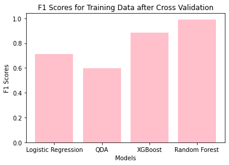

```python
models = ['Logistic Regression', 'QDA', 'XGBoost', 'Random Forest']
f1_cv_scores = [0.7097, 0.5952, 0.8835, 0.9908]
plt.bar(models, f1_cv_scores, color = "pink")
plt.xlabel("Models")
plt.ylabel("F1 Scores")
plt.title("F1 Scores for Training Data after Cross Validation")
plt.show()
```

From the plot above, we can see that the models with the best f1 scores after cross validation are the XGBoost model and Random Forest. But this plot is only after cross validating on the original fit data, because there were no hyperparameters to tune for either logistic regression or QDA.

Just for good measure, we will make a plot of the f1 scores of XGBoost and Random Forest after cross validating the hyperparameter-tuned models. And we will compare these values to the cross-validated f1 values of the logistic regression and QDA to ensure that XGBoost and Random Forest are still the two best performing models.

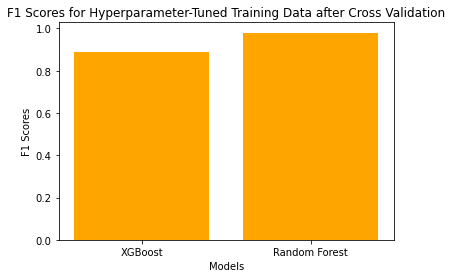

```python
models = ['XGBoost', 'Random Forest']
f1_cv_scores = [0.8903, 0.9795]
plt.bar(models, f1_cv_scores, color = "orange")
plt.xlabel("Models")
plt.ylabel("F1 Scores")
plt.title("F1 Scores for Hyperparameter-Tuned Training Data after Cross Validation")
plt.show()
```

The statement that XGBoost and Random Forest are our two best performing models still is true, and they do outperform logistic regression and QDA. Now, we can fit these two hyperparameter-tuned models to the testing data and evaluate our results.

# Final Model Evaluation

## XGBoost

```python
y_test_best_xgb = xgb_model_clf.predict(x_test)
print("XGB hyperparameter testing accuracy: ", accuracy_score(y_test, y_test_best_xgb))
xgb_hyper_report = classification_report(y_test_best_xgb, y_test)
print(xgb_hyper_report)
f1_hyper_xgb = f1_score(y_test, y_test_best_xgb, average = 'weighted')
print("F1 hyperparameter score: ", f1_hyper_xgb)
precision_hyper_xgb = precision_score(y_test, y_test_best_xgb, average = 'weighted')
print("Precision hyperparameter score: ", precision_hyper_xgb)
```

```
XGB hyperparameter testing accuracy:  0.8209000302023558
              precision    recall  f1-score   support

           0       0.90      0.88      0.89      8049
           1       0.52      0.59      0.56      1884

    accuracy                           0.82      9933
   macro avg       0.71      0.73      0.72      9933
weighted avg       0.83      0.82      0.82      9933

F1 hyperparameter score:  0.8170002157160839
Precision hyperparameter score:  0.8142074020575725
```

Compared to the training data that we used for the hyperparameter tuned model, the testing data predictions are slightly worse, but this isn't a bad thing. This is naturally bound to happen because there are more observations within the training dataset than the testing dataset, and the values are still good overall and not too far off from the training results. So from that, I think we can be confident that we didn't deal with a bad case of overfitting.

Let's now create a confusion matrix of these results so it's easier to visualize.

### Confusion Matrix

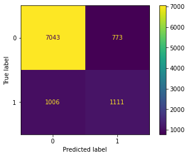

```python
from sklearn.metrics import ConfusionMatrixDisplay
confusion_matrix_xgb = confusion_matrix(y_test, y_test_best_xgb)
cm_plot_xgb = ConfusionMatrixDisplay(confusion_matrix_xgb)
cm_plot_xgb.plot()
plt.show()
```

Let's repeat the above process for the random forest.

## Random Forest

```python
y_test_best_rf = rf_model_clf.predict(x_test)
print("Random Forest hyperparameter testing accuracy: ", accuracy_score(y_test, y_test_best_rf))
rf_hyper_report = classification_report(y_test_best_rf, y_test)
print(rf_hyper_report)
f1_hyper_rf = f1_score(y_test, y_test_best_rf, average = 'weighted')
print("F1 hyperparameter score: ", f1_hyper_rf)
precision_hyper_rf = precision_score(y_test, y_test_best_rf, average = 'weighted')
print("Precision hyperparameter score: ", precision_hyper_rf)
```

```
Random Forest hyperparameter testing accuracy:  0.8341890667472063
              precision    recall  f1-score   support

           0       0.90      0.89      0.90      7873
           1       0.60      0.61      0.61      2060

    accuracy                           0.83      9933
   macro avg       0.75      0.75      0.75      9933
weighted avg       0.84      0.83      0.84      9933

F1 hyperparameter score:  0.8333589310944947
Precision hyperparameter score:  0.8325954747720856
```

Just like the XGBoost model, we still have a model that fits well, and with both models, we're able to capture bads more often than we aren't.

### Confusion Matrix

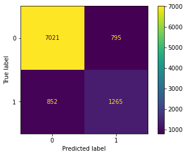

```python
confusion_matrix_rf = confusion_matrix(y_test, y_test_best_rf)
cm_plot_rf = ConfusionMatrixDisplay(confusion_matrix_rf)
cm_plot_rf.plot()
plt.show()
```

# Conclusion and Findings

Just like how we did with the training data, let's make a plot of the f1 scores to see which model performed better.

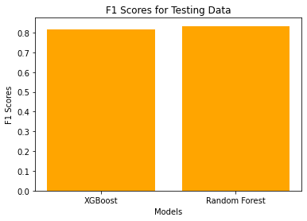

```python
models = ['XGBoost', 'Random Forest']
f1_cv_scores = [0.817, 0.8334]
plt.bar(models, f1_cv_scores, color = "orange")
plt.xlabel("Models")
plt.ylabel("F1 Scores")
plt.title("F1 Scores for Testing Data")
plt.show()
```

From f1 score, we can see that random forest was the best performing model. We have a lot of metrics in the tables, but the final metric I want to compute is ROC-AUC. ROC-AUC calculates a model's ability to distinguish classes in a binary classification problem by comparing the true positive rate to the false positive rate.

```python
from sklearn.metrics import roc_auc_score
xgb_best_roc = roc_auc_score(y_test, y_test_best_xgb)
print("XGB Final test ROC-AUC:", xgb_best_roc)
rf_best_roc = roc_auc_score(y_test, y_test_best_rf)
print("Random Forest Final test ROC-AUC:", rf_best_roc)
```

```
XGB Final test ROC-AUC: 0.7129497756379729
Random Forest Final test ROC-AUC: 0.747914630985989
```

A higher ROC-AUC score is better, so by looking at both f1 score and ROC-AUC, the random forest model is the best performing model. I am not too surprised by this result given how the model was performing before any cross-validation or oversampling happened, and this can be attributed to the robustness of the model. With a combination of both continuous and dummified variables that were used, it makes sense that decision-tree based models would perform better than non decision-tree based models, which is also why the XGBoost model performed well with data to begin with. The difference in performance with the training and testing data is expected because the new data wasn't trained on.

It's a very good sign that both the random forest and XGBoost models were able to predict on bad candidates. This is something that companies need to be watchful for when deciding who to give credit cards to. The more "bad" candidates you're able to catch, the more you're able to protect your risk as a company.

It's also worth noting that the criteria that I selected for my `GOOD_BAD` variable is much simpler than what is actually used in real-life scenarios. But this project was still a fun one that aligned with my interests in risk and decision making, and might be one that I continue building upon with unsupervised learning techniques as I progress as a data scientist.